# Лабораторная работа №7

Анализ файловой системы Linux. Команды для работы с файлами и каталогами

Липатников Андрей

1032253853@rudn.ru

Российский университет дружбы народов

2026-10-08

# Информация

## Докладчик

- Липатников Андрей
- Студент Российского университета дружбы народов им. П. Лумумбы
- 1032253853@rudn.ru

# Вводная часть

## Актуальность

- 90% работы администратора Linux — терминал и файловая система
- Ошибки в правах доступа — источник уязвимостей и потери данных
- `fsck` и `mkfs` — последние инструменты спасения при сбое диска

## Цель и задачи

- Цель: ознакомление с файловой системой Linux, её структурой, именами и содержанием каталогов; практические навыки работы с файлами и каталогами, процессами и обслуживанием ФС
- Задачи:
  - Выполнить примеры методических указаний
  - Определить опции `chmod` для заданных прав
  - Выполнить упражнения с `feathers` и `play`
  - Прочитать `man` по `mount`, `fsck`, `mkfs`, `kill`
  - Ответить на контрольные вопросы

# Материалы и методы

## Среда и методика

- **ОС**: Fedora 41 (Sway) в VirtualBox, терминал bash
- **Инструменты**: стандартные утилиты GNU (`touch`, `cp`, `mv`, `chmod`, `mount`, `df`, `fsck`, `mkfs`, `kill`)
- Методика: задание из методички — справка `man` — фиксация скриншотом
- Все 27 шагов задокументированы снимками

# Содержание исследования

## Файлы и каталоги

- Создание и просмотр: `touch`, `cat`, `less`, `head`, `tail`
- Копирование: `cp` (опция `-r` для каталогов)
- Перемещение и переименование: `mv` — файлы и каталоги

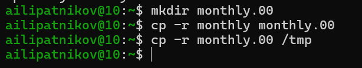

## Права доступа: chmod

- Символьная форма: `chmod u+x may`, `chmod g-r,o-r monthly`
- Числовая форма: `australia` — 744 (`rwxr--r--`), `my_os` — 544 (`r-xr--r--`)
- Ключевой вывод: право `x` для каталога — право входа в него

## Анализ и обслуживание файловой системы

- Анализ: `mount` (список ФС), `df` (свободное место), `/etc/fstab` (статическая конфигурация)
- Обслуживание: `fsck` — проверка целостности, `mkfs` — создание ФС
- Обе операции требуют прав root

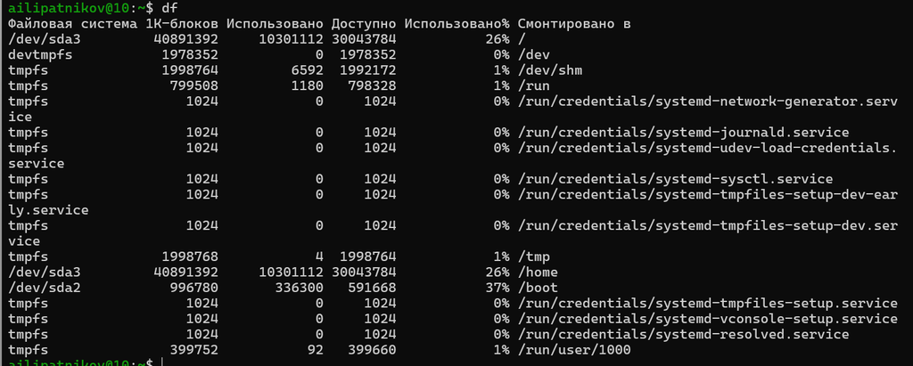

## Управление процессами

- `kill PID` — сигнал завершения (SIGTERM по умолчанию)
- `kill -9 PID` — принудительный SIGKILL

# Результаты

## Полученные результаты

| Результат | Команды |
| --- | --- |
| Файлы и каталоги | `touch`, `cat`, `less`, `head`, `tail`, `cp`, `mv`, `mkdir` |
| Права доступа | `chmod` (символьная и числовая формы) |
| Анализ ФС | `mount`, `df`, `cat /etc/fstab` |
| Обслуживание ФС и процессы | `fsck`, `mkfs`, `kill` |

# Заключение

## Главный вывод

Освоены команды работы с файлами и каталогами, управление правами доступа в двух формах записи, анализ и обслуживание файловой системы Linux и управление процессами. Командная строка — универсальный инструмент администрирования, и эти навыки — основа всех последующих лабораторных работ курса.

# Резерв

## Резерв: примеры первой части методички

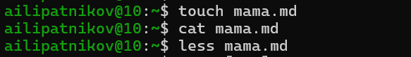

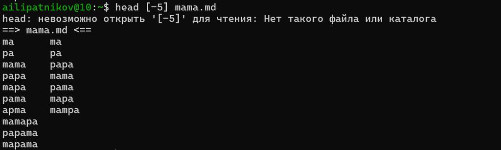

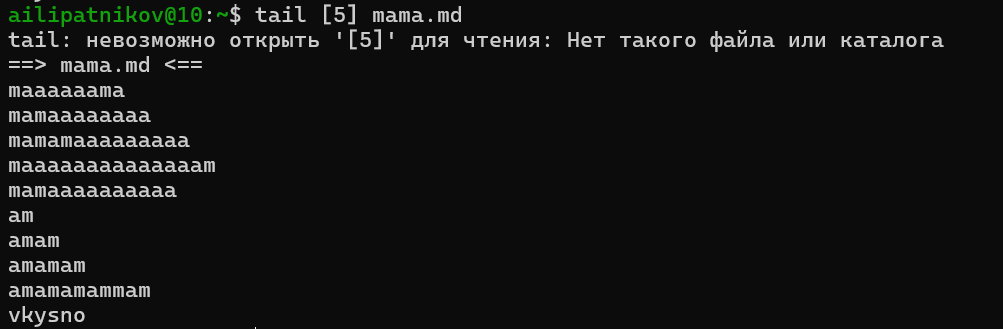

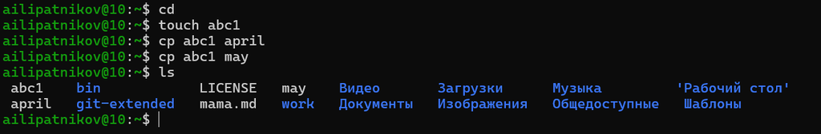

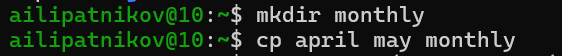

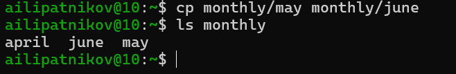

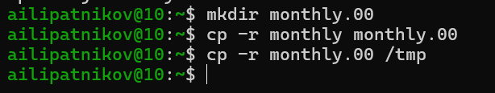

## Резерв: переименование и перемещение

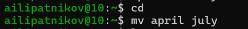

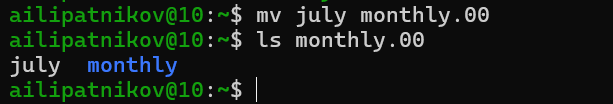

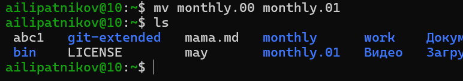

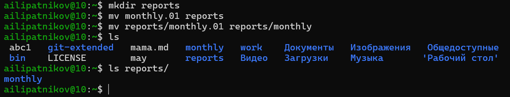

## Резерв: права доступа и проверка ФС

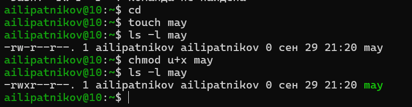

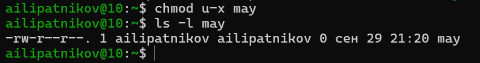

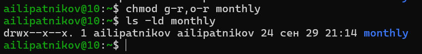

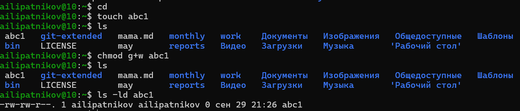

## Резерв: анализ файловой системы

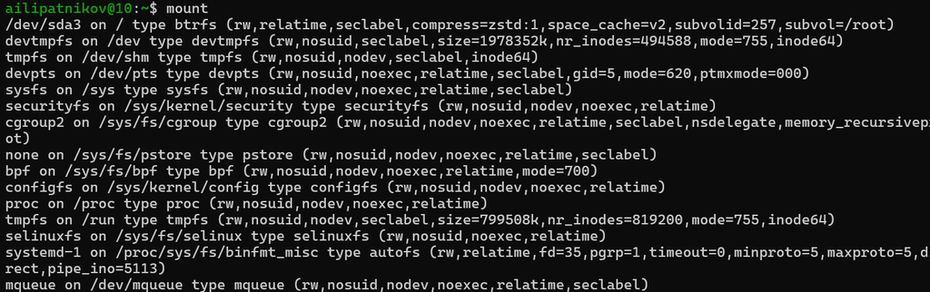

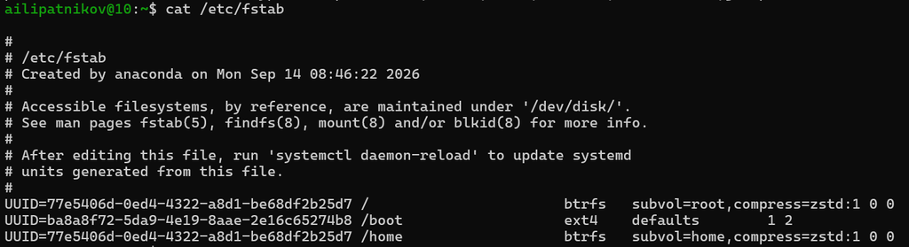

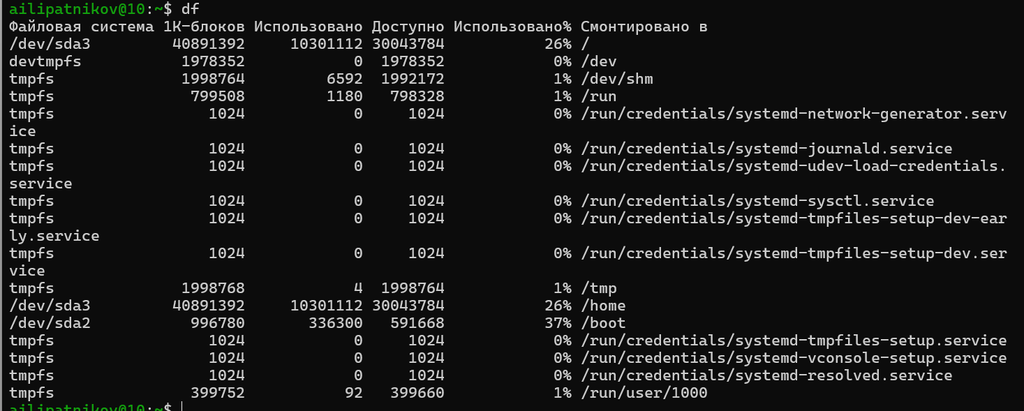

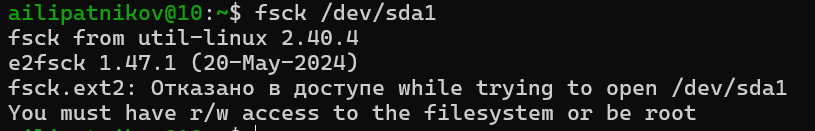

## Резерв: упражнения feathers и play

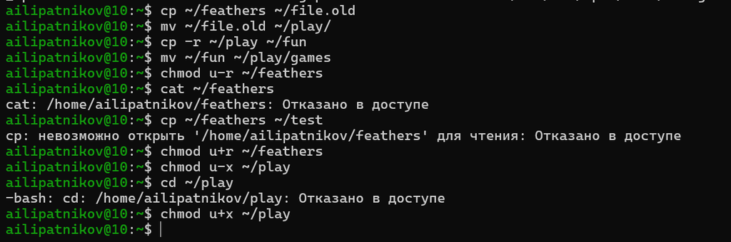

## Резерв: ski.plases и восьмеричные права

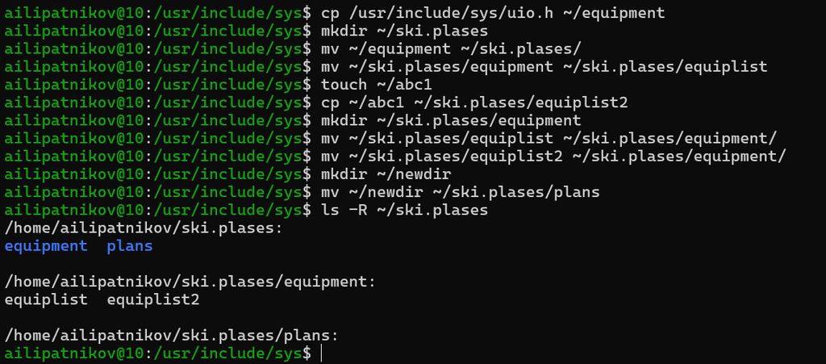

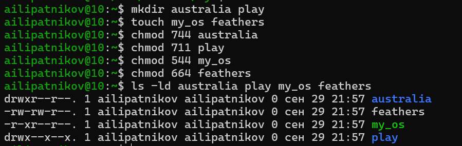